# Homework #3

Aleksander Molak

May 1, 2019

## Import required libraries

```r
library(foreign)    # read in SPSS craziness into eel-readable, sorry, R-readable format

library(nlme)       # MLM
library(lme4)       # MLM
library(lmtest)     # Compare models using likelihood ratio test

library(ggplot2)    # get quality plots, baby!
library(sjPlot)     # Plot variability in intercepts and slopes easily
library(lattice)    # xyplot()

library(dplyr)      # make your life easier :)
library(QuantPsyc)  # get standardized coefficients!
library(effects)
library(vcd)
library(car)        # logit()
```

# Part 1

Data file: time.sav

The data set you received has a long format (which means that you do not have to transform it) and includes the following variables:

- **id**: level-2 variable; participant’s identifier (1-50)
- **time**: level-1 variable; time index, takes values from 0 to 15
- **intimacy**: level-1 variable; perceived level of intimacy in the relationship (takes values from 0 to 10)
- **treatment**: level-2 variable; study condition; 0 = waiting list, 1 = treatment group

## Load, transform and examine the data

```r
# Set working dir.
setwd(path)

# Import the data
data_1 <- read.spss("time.sav", to.data.frame=TRUE)

# Check for NAs
sum(is.na(data_1))
```

```
## [1] 0
```

No NAs in the dataset. Hurray! :)

## Visualize the raw data (4 points)

#### Let’s start with visualizing raw data. Create two plots with time as the x variable and intimacy as the y variable.

#### a.) In the first plot show the raw results for each study participant and connect them with lines

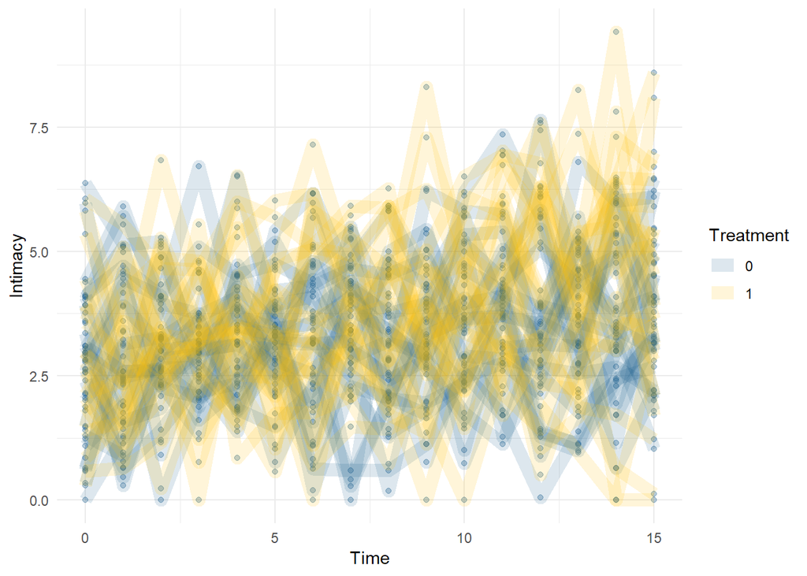

Figure 1. Intimacy level per participant vs time vs treatment (0 = no treatment; 1 = treatment)

```r
ggplot(data_1, aes(x = time, y = intimacy, group = id, colour = factor(treatment))) +
                            geom_point(color = color, alpha = .3) +
                            geom_line(size = 4, alpha = .15) +
                            labs(x = "Time", y = "Intimacy", colour = "Treatment") +
                            theme_minimal() +
                            scale_color_manual(values=c(color, color4))
```

#### b) Create a spaghetti plot showing regression lines estimated for each person independently (use geom_smooth() function but do not facet_wrap() function)

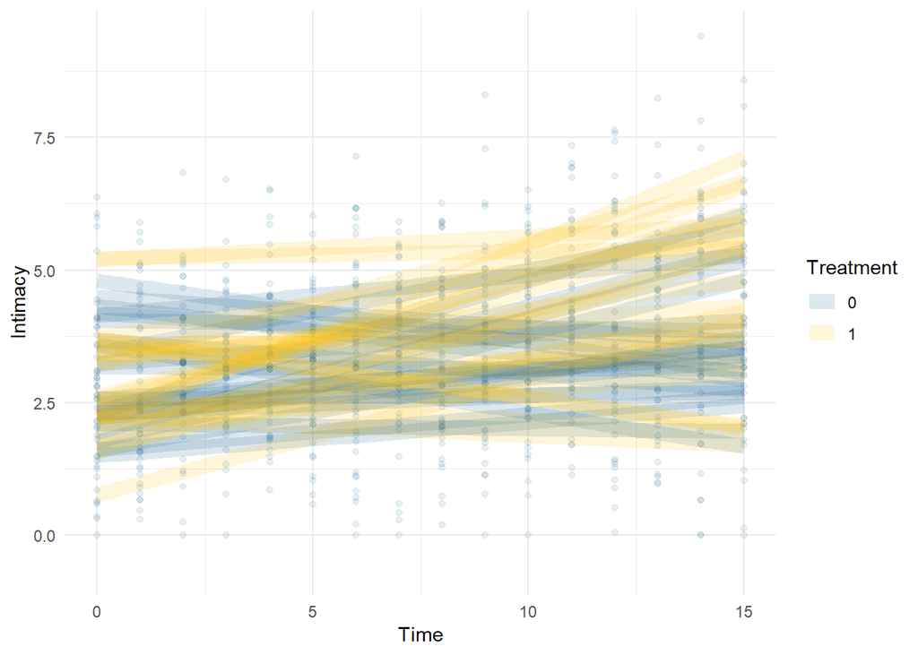

Figure 2. Linear regression lines for intimacy level per participant per timepoint. Colours signify treatment (0 = no treatment; 1 = treatment)

```r
ggplot(data_1, aes(x = time, y = intimacy, group = id, colour = factor(treatment))) +
                            geom_point(color = color, alpha = .1) +
                            geom_line(stat = "smooth", method = lm, size = 4, alpha = .15) +
                            labs(x = "Time", y = "Intimacy", colour = "Treatment") +
                            theme_minimal() +
                            scale_color_manual(values=c(color, color4))
```

## Null model (4 points)

#### Fit a null model with intimacy as the DV and respond the following questions:

```r
# Null model
model_0 <- lme(fixed = intimacy ~ 1, random = ~1|id, data = data_1)

# Summarize `model_0`
summary_0 <- summary(model_0)
summary_0
```

```
## Linear mixed-effects model fit by REML
##  Data: data_1
##        AIC      BIC    logLik
##   2936.987 2951.037 -1465.493
##
## Random effects:
##  Formula: ~1 | id
##         (Intercept) Residual
## StdDev:   0.8049621 1.427089
##
## Fixed effects: intimacy ~ 1
##                Value Std.Error  DF  t-value p-value
## (Intercept) 3.468712 0.1245191 750 27.85687       0
##
## Standardized Within-Group Residuals:
##         Min          Q1         Med          Q3         Max
## -2.99215922 -0.65963069 -0.04242062  0.61779045  3.47832287
##
## Number of Observations: 800
## Number of Groups: 50
```

#### a) Provide the estimate, SE and p-value for intercept. How can you interpret this value?

```r
cat("Estimate:", summary_0$tTable[, "Value"])
```

```
## Estimate: 3.468712
```

```r
cat("SE:", summary_0$tTable[, "Std.Error"])
```

```
## SE: 0.1245191
```

```r
cat("p-value:", summary_0$tTable[, "p-value"])
```

```
## p-value: 8.414822e-118
```

Intercept value $3.47$ means that the mean value of `intimacy` in the sample equals to $3.47$.

#### b) What amount of variability in intimacy may be attributed to interindividual factors (in other words, what is the value of ICC)?

```r
# Get variances
vc_0 <- as.numeric(VarCorr(model_0))

# Compute ICC
icc_0 <- vc_0[1] / (vc_0[1] + vc_0[2])

# Print out
cat("ICC =", icc_0)
```

```
## ICC = 0.241368
```

## Model with fixed time predictor (5 points)

#### Fit a model with time as a fixed level-1 predictor and respond the following questions.

```r
# Model with fixed level-1 predictor
model_1 <- lme(fixed = intimacy ~ time, random = ~1|id, data = data_1)


# Summarize `model_1`
summary_1 <- summary(model_1)
summary_1
```

```
## Linear mixed-effects model fit by REML
##  Data: data_1
##        AIC      BIC   logLik
##   2891.221 2909.949 -1441.61
##
## Random effects:
##  Formula: ~1 | id
##         (Intercept) Residual
## StdDev:   0.8104389 1.376601
##
## Fixed effects: intimacy ~ time
##                 Value  Std.Error  DF   t-value p-value
## (Intercept) 2.8707529 0.14756466 749 19.454203       0
## time        0.0797279 0.01055805 749  7.551392       0
##  Correlation:
##      (Intr)
## time -0.537
##
## Standardized Within-Group Residuals:
##         Min          Q1         Med          Q3         Max
## -2.84922491 -0.64144124 -0.04986546  0.63864535  3.21974344
##
## Number of Observations: 800
## Number of Groups: 50
```

#### a) Is this model better than the null model? Provide the results of an appropriate test

```r
lrtest(model_0, model_1)
```

```
## Likelihood ratio test
##
## Model 1: intimacy ~ 1
## Model 2: intimacy ~ time
##   #Df  LogLik Df  Chisq Pr(>Chisq)
## 1   3 -1465.5
## 2   4 -1441.6  1 47.766  4.803e-12 ***
## ---
## Signif. codes:  0 '***' 0.001 '**' 0.01 '*' 0.05 '.' 0.1 ' ' 1
```

According to likelihood ratio test `model_1` is better than `model_0`. Deviance difference between `model_0` and `model_1` equals to $47.77$ and is significant at $p<.001$.

#### b) What is the value of the intercept? How would you interpret it?

```r
cat("Estimate:", summary_1$tTable[1, "Value"])
```

```
## Estimate: 2.870753
```

Value of the intercept equals to $2.87$. It can be interpreted as a mean level of intimacy at time $0$.

#### c) Is the effect of time significant? If so, how would you interpret its value?

```r
# Check significance
summary_1$tTable["time", "p-value"] < .001
```

```
## [1] TRUE
```

Yes, it is significant at $p < .001$. It can be interpreted as expected increase in `intimacy` due to increment of one unit in `time`.

## Model with random time predictor (7 points)

#### Fit a model with time as a random level-1 predictor and respond the following questions.

```r
# Model with time as random level-1 predictor
model_2 <- lme(fixed = intimacy ~ time, random = ~time | id, data = data_1)


# Summarize `model_2`
summary_2 <- summary(model_2)
summary_2
```

```
## Linear mixed-effects model fit by REML
##  Data: data_1
##        AIC     BIC    logLik
##   2855.878 2883.97 -1421.939
##
## Random effects:
##  Formula: ~time | id
##  Structure: General positive-definite, Log-Cholesky parametrization
##             StdDev    Corr
## (Intercept) 0.8152800 (Intr)
## time        0.0954216 -0.435
## Residual    1.3009607
##
## Fixed effects: intimacy ~ time
##                 Value  Std.Error  DF   t-value p-value
## (Intercept) 2.8707529 0.14494631 749 19.805630       0
## time        0.0797279 0.01678286 749  4.750558       0
##  Correlation:
##      (Intr)
## time -0.585
##
## Standardized Within-Group Residuals:
##         Min          Q1         Med          Q3         Max
## -2.61067872 -0.67299975 -0.01486599  0.64529974  2.47682364
##
## Number of Observations: 800
## Number of Groups: 50
```

#### a) Is this model better than the model with time as a fixed predictor? Provide the results of an appropriate test.

```r
lrtest(model_1, model_2)
```

```
## Likelihood ratio test
##
## Model 1: intimacy ~ time
## Model 2: intimacy ~ time
##   #Df  LogLik Df  Chisq Pr(>Chisq)
## 1   4 -1441.6
## 2   6 -1421.9  2 39.343  2.862e-09 ***
## ---
## Signif. codes:  0 '***' 0.001 '**' 0.01 '*' 0.05 '.' 0.1 ' ' 1
```

According to likelihood ratio test `model_2` is better than `model_1`. Deviance difference between `model_1` and `model_2` equals to $39.34$ and is significant at $p<.001$.

#### b) What is the value of the time slope? How would you interpret it?

```r
# Get time slope value
summary_1$tTable[2, 1]
```

```
## [1] 0.07972794
```

#### c) Is the variability in time slopes between study subjects statistically significant?

```r
intervals(model_2, which = 'var-cov')
```

```
## Approximate 95% confidence intervals
##
##  Random Effects:
##   Level: id
##                             lower       est.       upper
## sd((Intercept))        0.59136238  0.8152800  1.12398333
## sd(time)               0.07005738  0.0954216  0.12996892
## cor((Intercept),time) -0.70802500 -0.4348035 -0.04835948
##
##  Within-group standard error:
##    lower     est.    upper
## 1.234549 1.300961 1.370945
```

Yes.

#### How do you know it?

$95$% confidence interval for $\sqrt{\tau_{11}}$ does not contain $0$.

#### Provide and interpret 95% PVI for time slopes

```r
# Get std of random slope
std_r_slope <- 0.0954216


# Compute PVIs

m_2_pvi <- std_r_slope * 1.96

m_2_beta_10 <- 0.0797279

m_2_upper_bound_pvi <- m_2_beta_10 + m_2_pvi
m_2_lower_bound_pvi <- m_2_beta_10 - m_2_pvi

cat("PVI for time slopes:", m_2_lower_bound_pvi, m_2_upper_bound_pvi)
```

```
## PVI for time slopes: -0.1072984 0.2667542
```

$95$% of random `time` slopes should take values between $-.11$ and $.27$

#### d) Create a model-based spaghetti plot showing the relationship between time and intimacy.

```r
# Compute fitted values for `model_2` and add them to our dataframe
data_1$predicted_m2_random <- fitted(model_2)
```

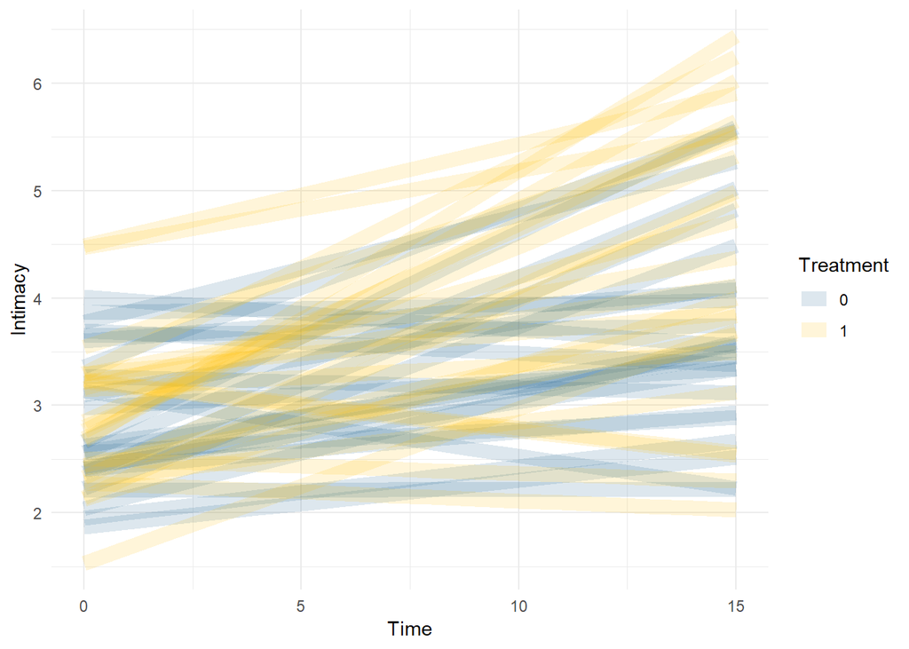

Figure 3. Fitted lines (`model_2`). Intimacy level for each participant predicted by time. Colours signify treatment (0 = no treatment; 1 = treatment)

```r
ggplot(data_1, aes(x = time, y = predicted_m2_random, group = id, colour = factor(treatment))) +
                            geom_line(size = 4, alpha = .15) +
                            labs(x = "Time", y = "Intimacy", colour = "Treatment") +
                            theme_minimal() +
                            scale_color_manual(values=c(color, color4))
```

#### e) What is the correlation between intercepts and time slopes?

$r = -.44$

#### Is it significant?

Yes. $95$% confidence interval does not contain $0$ ($CI$ $[-.71, -.05]$)

#### How would you interpret it?

The correlation is negative. This means that the bigger the value of the intercept (value of `intimacy` at `time == 0`) the lower the value of the slope (slower increase or decrease-instead-of-increase in `intimacy` over time).

#### f) Create a plot showing the variability in intercepts and slopes (**1 EXTRA POINT**).

```r
# Recreate the model using lmer() - sjPlot does not support models built using lme()
model_2_lmer <- lmer(intimacy ~ time + (1 + time | id), data_1)
```

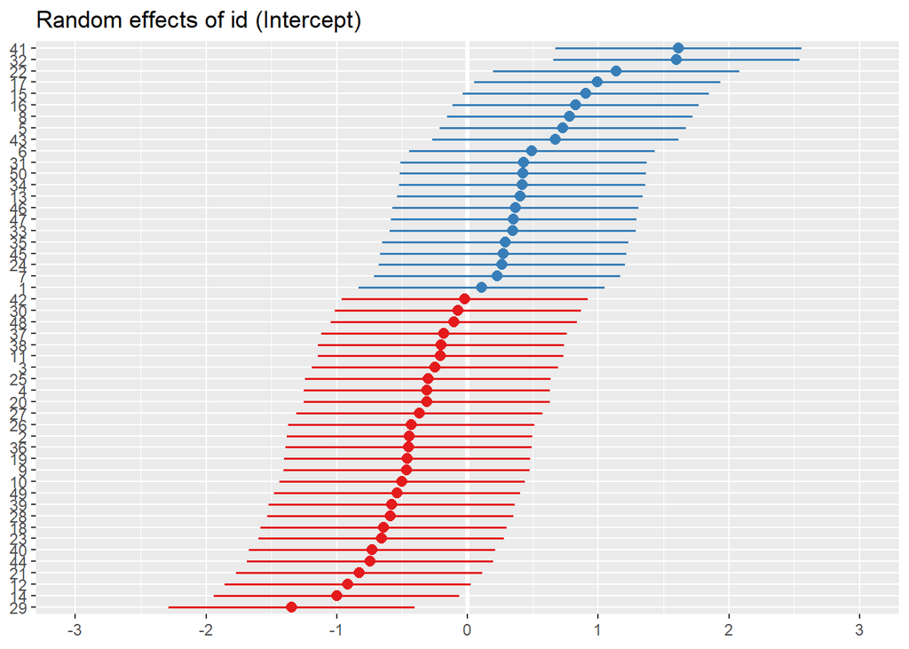

Figure 4. Variablilty of intercept [1] and slope [2] for `model_2`.

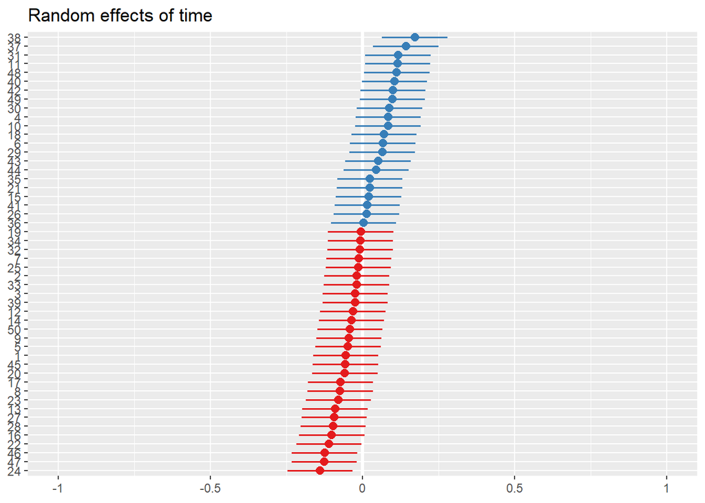

Figure 4. Variablilty of intercept [1] and slope [2] for `model_2`.

```r
plot_model(model_2_lmer,
           type = "re",
           sort.est = "sort.all",
           grid = FALSE,
           free.scale = FALSE)
```

## Model with time interaction (5 points)

#### Fit a model with `time` as a random level-1 predictor, `treatment` as level-2 time-invariant predictor and `time × treatment` interaction. Respond the following questions.

```r
model_3 <- lme(fixed = intimacy ~ time + treatment + time*treatment, random = ~ time | id, data = data_1)
summary_3 <- summary(model_3)
summary_3
```

```
## Linear mixed-effects model fit by REML
##  Data: data_1
##        AIC      BIC    logLik
##   2861.224 2898.661 -1422.612
##
## Random effects:
##  Formula: ~time | id
##  Structure: General positive-definite, Log-Cholesky parametrization
##             StdDev    Corr
## (Intercept) 0.8280903 (Intr)
## time        0.0917385 -0.453
## Residual    1.3009608
##
## Fixed effects: intimacy ~ time + treatment + time * treatment
##                     Value  Std.Error  DF   t-value p-value
## (Intercept)     2.8989735 0.20702887 748 14.002750  0.0000
## time            0.0490135 0.02314640 748  2.117545  0.0345
## treatment      -0.0564412 0.29278304  48 -0.192775  0.8479
## time:treatment  0.0614288 0.03273395 748  1.876609  0.0610
##  Correlation:
##                (Intr) time   trtmnt
## time           -0.599
## treatment      -0.707  0.423
## time:treatment  0.423 -0.707 -0.599
##
## Standardized Within-Group Residuals:
##         Min          Q1         Med          Q3         Max
## -2.62424617 -0.67982625 -0.01899984  0.64335499  2.44629657
##
## Number of Observations: 800
## Number of Groups: 50
```

#### a) Is this model better than the model with time as a random predictor? Provide the results of an appropriate test.

```r
lrtest(model_2, model_3)
```

```
## Likelihood ratio test
##
## Model 1: intimacy ~ time
## Model 2: intimacy ~ time + treatment + time * treatment
##   #Df  LogLik Df  Chisq Pr(>Chisq)
## 1   6 -1421.9
## 2   8 -1422.6  2 1.3465     0.5101
```

`model_3` is not better than `model_2`. $\chi^2$ test is not significant.

#### b) Is variability in slopes explained by study condition? How do you know it?

```r
summary_3 <- summary(model_3)

cat(" Expected difference in slopes between study conditions equals", summary_3$tTable['time:treatment', 'Value'],
    "\n",
    "This difference is not significant at customary level of p = .05. P-value:", summary_3$tTable['time:treatment', 'p-value'], "\n",
    "Thus we can conclude, that variability in slopes is not being explained by study condition.")
```

```
##  Expected difference in slopes between study conditions equals 0.06142882
##  This difference is not significant at customary level of p = .05. P-value: 0.06096078
##  Thus we can conclude, that variability in slopes is not being explained by study condition.
```

#### c) Do treatment and waiting list group differ in terms of intercepts? How do you know it?

```r
# Add reverse-coding `treatment`
data_1$no_treatment <- recode(data_1$treatment,'0=1;1=0')

# Fit the model with recoded `treatment`
model_3_rcd <- lme(fixed = intimacy ~ time + no_treatment + time * no_treatment, random = ~ time | id, data = data_1)
summary_3_rcd <- summary(model_3_rcd)
summary_3_rcd
```

```
## Linear mixed-effects model fit by REML
##  Data: data_1
##        AIC      BIC    logLik
##   2861.224 2898.661 -1422.612
##
## Random effects:
##  Formula: ~time | id
##  Structure: General positive-definite, Log-Cholesky parametrization
##             StdDev    Corr
## (Intercept) 0.8280903 (Intr)
## time        0.0917385 -0.453
## Residual    1.3009608
##
## Fixed effects: intimacy ~ time + no_treatment + time * no_treatment
##                        Value  Std.Error  DF   t-value p-value
## (Intercept)        2.8425324 0.20702887 748 13.730125  0.0000
## time               0.1104424 0.02314640 748  4.771471  0.0000
## no_treatment       0.0564412 0.29278304  48  0.192775  0.8479
## time:no_treatment -0.0614288 0.03273395 748 -1.876609  0.0610
##  Correlation:
##                   (Intr) time   n_trtm
## time              -0.599
## no_treatment      -0.707  0.423
## time:no_treatment  0.423 -0.707 -0.599
##
## Standardized Within-Group Residuals:
##         Min          Q1         Med          Q3         Max
## -2.62424617 -0.67982625 -0.01899984  0.64335499  2.44629657
##
## Number of Observations: 800
## Number of Groups: 50
```

```r
summary_3_rcd
```

```
## Linear mixed-effects model fit by REML
##  Data: data_1
##        AIC      BIC    logLik
##   2861.224 2898.661 -1422.612
##
## Random effects:
##  Formula: ~time | id
##  Structure: General positive-definite, Log-Cholesky parametrization
##             StdDev    Corr
## (Intercept) 0.8280903 (Intr)
## time        0.0917385 -0.453
## Residual    1.3009608
##
## Fixed effects: intimacy ~ time + no_treatment + time * no_treatment
##                        Value  Std.Error  DF   t-value p-value
## (Intercept)        2.8425324 0.20702887 748 13.730125  0.0000
## time               0.1104424 0.02314640 748  4.771471  0.0000
## no_treatment       0.0564412 0.29278304  48  0.192775  0.8479
## time:no_treatment -0.0614288 0.03273395 748 -1.876609  0.0610
##  Correlation:
##                   (Intr) time   n_trtm
## time              -0.599
## no_treatment      -0.707  0.423
## time:no_treatment  0.423 -0.707 -0.599
##
## Standardized Within-Group Residuals:
##         Min          Q1         Med          Q3         Max
## -2.62424617 -0.67982625 -0.01899984  0.64335499  2.44629657
##
## Number of Observations: 800
## Number of Groups: 50
```

```r
# Compare estimates for `treatment` (`model_3`) and `no_treatment` (`model_3_rcd`) models
cat("                         Estimate  Std. Error  DF          z value     Pr(>|z|) \n",
    "No treatment         :", "\n",
    "          (Intercept):", formatC(summary_3$tTable[1, ], digits = 8, format = 'f'), "\n",
    "Treatment            :", "\n",
    "          (Intercept):", formatC(summary_3_rcd$tTable[1, ], digits = 8, format = 'f'))
```

```
##                          Estimate  Std. Error  DF          z value     Pr(>|z|)
##  No treatment         :
##            (Intercept): 2.89897353 0.20702887 748.00000000 14.00275012 0.00000000
##  Treatment            :
##            (Intercept): 2.84253235 0.20702887 748.00000000 13.73012545 0.00000000
```

#### e) Provide a publication-quality table summarizing all models you have just tested. You can find an example of such table in the revised Class 7 slides (**2 EXTRA POINTS**)

```r
# Recreate all models using lmer() to use with tab_model()
model_0_lmer <- lmer(intimacy ~ 1 + (1 | id), data_1)
model_1_lmer <- lmer(intimacy ~ time + (1 | id), data_1)
model_2_lmer <- lmer(intimacy ~ time + (1 + time | id), data_1)

# `model-3_lmer` -> add comments below;
model_3_lmer <- lmer(intimacy ~ time*treatment + (1 + time | id), data_1,
                     control = lmerControl(optimizer ="Nelder_Mead"))
# Optimization method changed due to problems in convergence using default optimizer (bobyqa)
# NOTE: There's no need to specify interaction terms separately - lmer() will incluse them automatically
```

```r
# Build the comparison table
tab_model(model_0_lmer, model_1_lmer, model_2_lmer, model_3_lmer,

          show.ci      = FALSE,
          show.dev     = TRUE,
          show.r2      = FALSE,
          show.ngroups = FALSE,
          show.obs     = FALSE,
          p.style      = 'asterisk',

          pred.labels = c("Intercept",
                          "Time",
                          "Treatment",
                          "Time × Treatment"),

          dv.labels   = c("Model 0",
                          "Model 1",
                          "Model 2",
                          "Model 3"),

          title = "Table 1. Comparison of models: `model_0`, `model_1`, `model_2`, `model_3`")
```

```
## Computing p-values via Wald-statistics approximation (treating t as Wald z).
## Computing p-values via Wald-statistics approximation (treating t as Wald z).
## Computing p-values via Wald-statistics approximation (treating t as Wald z).
## Computing p-values via Wald-statistics approximation (treating t as Wald z).
```

Table 1. Comparison of models: `model_0`, `model_1`, `model_2`, `model_3`

Model 0

Model 1

Model 2

Model 3

Predictors

Estimates

Estimates

Estimates

Estimates

Intercept

3.47 ***

2.87 ***

2.87 ***

2.90 ***

Time

0.08 ***

0.08 ***

0.05 *

Treatment

-0.06

Time × Treatment

0.06

Random Effects

σ<sup>2</sup>

2.04

1.90

1.69

1.69

τ<sub>00</sub>

0.65 <sub>id</sub>

0.66 <sub>id</sub>

0.66 <sub>id</sub>

0.69 <sub>id</sub>

τ<sub>11</sub>

0.01 <sub>id.time</sub>

0.01 <sub>id.time</sub>

ρ<sub>01</sub>

-0.43 <sub>id</sub>

-0.45 <sub>id</sub>

ICC

0.24

0.26

0.34

0.33

Deviance

2928.658

2873.626

2835.094

2830.314

- p<0.05 ** p<0.01 *** p<0.001

# Part 2

Data file: ESS8.3.sav

In the second part of Homework 3 you are going to analyse data from the 8th wave (2016) wave of the European Social Survey. The study was conducted in 23 European countries. The data set you received has a two-level structure:

**individuals** (level-1 units) are nested in **countries** (level-2 units).

Your task would be to check what factors explain boycotting certain products (as a form of protest behaviour) in the last 12 months.

The dataset you received includes the following variables:

- **cntry**: level-2 group identifier; respondent’s country level-2 variable; is gay marriage legal in a given country (2016)? 0 = no, 1 = yes
- **gdp**: level-2 variable; country’s GDP per capita in 10 000$ (World Bank data)
- **full_democracy**: level-2 variable; based on the Economist Democracy Index; is this country a full democracy? 0 = no, 1 = yes
- **bctprd**: level-1 variable; boycotting certain products in the last 12 months 0 = no, 1 = yes
- **lrscale**: level-1 variable; left – right self-placement (0 = left, 10 = right);

**HINT**: Do not forget about grand mean centering of continuous lrscale and gdp.

## Load and transform the data

```r
# Import the data
data_2 <- read.spss("ESS8.3.sav", to.data.frame=TRUE)
```

```
## re-encoding from UTF-8
```

```r
# Mean-center the L-R scale and add to the dataframe
data_2$lrscale_centered <- data_2$lrscale - mean(data_2$lrscale)

# Check if # of obs per country is equal for all countries
# data_2 %>%
#   group_by(cntry) %>%
#   tally() %>%
#   select(n) %>%
#   unique()                 # Needed to comment this code out as knitr() was not able to run it
```

Number of obs. per country is not identical for each country. We need to get mean $GDP$ for each country and then get a grand mean of each country’s mean $GDP$ to get a reliable estimate of grand mean.

```r
# Aggregate GDP and get per-country means
gdp_aggregated <- aggregate(data_2$gdp, by=list(data_2$cntry), mean)

# Center GDP (using grand mean of country means)
data_2$gdp_centered <- data_2$gdp - mean(gdp_aggregated$x)
```

## Visualize distributions

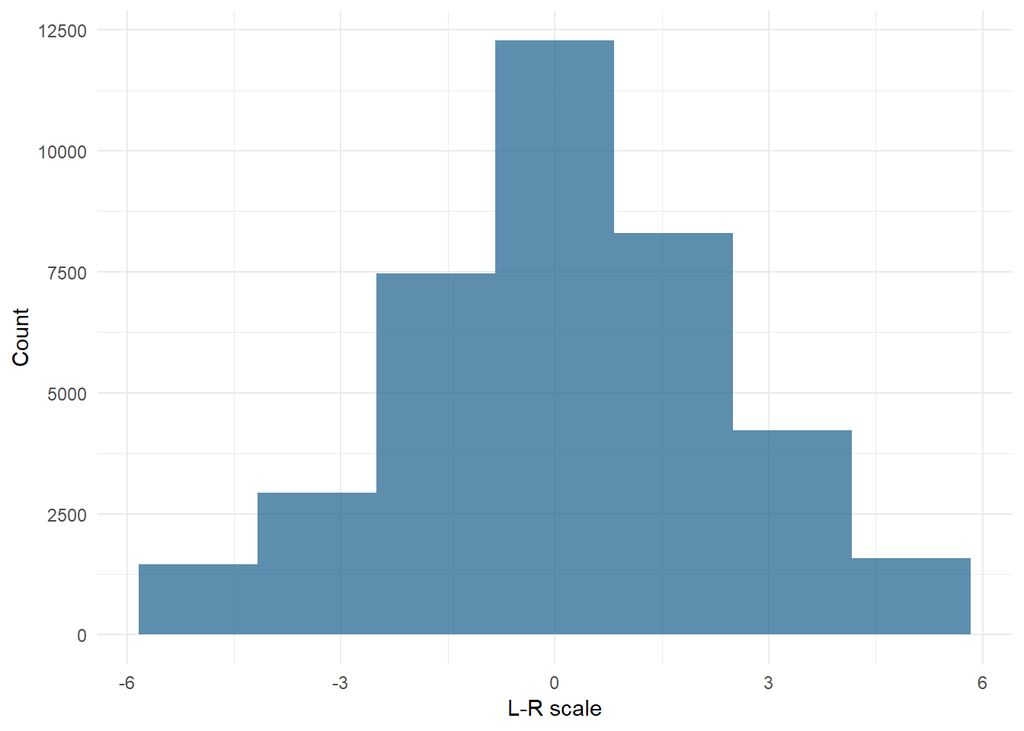

Figure 5. Histogram: L-R scale (centered).

```r
# Histogrm: ID with the socil mvmnt
ggplot(data_2, aes(lrscale_centered)) + geom_histogram(bins=7, fill=color, alpha=.7) +
                           xlab('L-R scale') +
                           ylab('Count') +
                           theme_minimal()
```

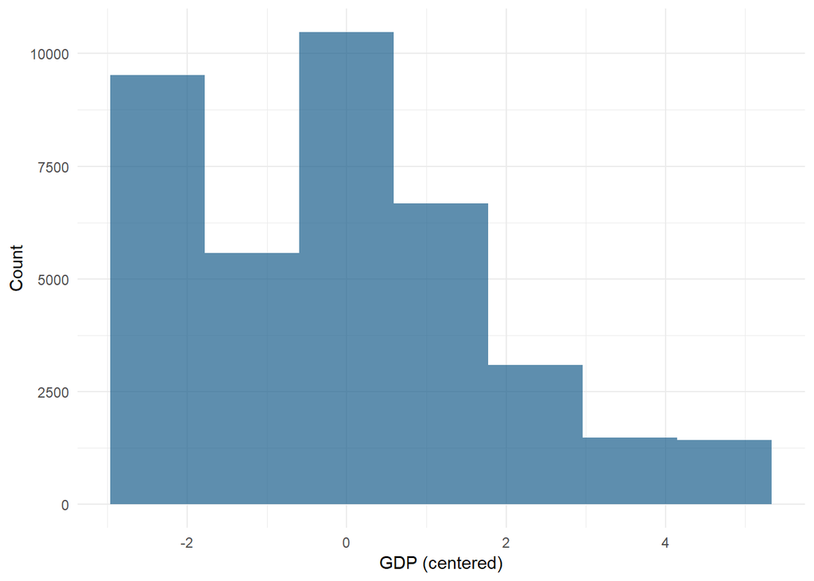

Figure 6. Histogram: GDP (centered)

```r
# Histogrm: ID with the socil mvmnt
ggplot(data_2, aes(gdp_centered)) + geom_histogram(bins=7, fill=color, alpha=.7) +
                           xlab('GDP (centered)') +
                           ylab('Count') +
                           theme_minimal()
```

## Null model (5 points)

#### Fit a multilevel null model with bctprd as the DV and respond the following questions:

```r
# Null model - using glmer, because DV is binomial
model_20 <- glmer(bctprd ~ 1 + (1 | cntry), family = binomial, data = data_2)

# Get summary
summary_20 <- summary(model_20)
summary_20
```

```
## Generalized linear mixed model fit by maximum likelihood (Laplace
##   Approximation) [glmerMod]
##  Family: binomial  ( logit )
## Formula: bctprd ~ 1 + (1 | cntry)
##    Data: data_2
##
##      AIC      BIC   logLik deviance df.resid
##  34296.8  34313.9 -17146.4  34292.8    38240
##
## Scaled residuals:
##     Min      1Q  Median      3Q     Max
## -0.9650 -0.5387 -0.3260 -0.1921  6.0533
##
## Random effects:
##  Groups Name        Variance Std.Dev.
##  cntry  (Intercept) 0.8717   0.9337
## Number of obs: 38242, groups:  cntry, 23
##
## Fixed effects:
##             Estimate Std. Error z value Pr(>|z|)
## (Intercept)  -1.6456     0.1947  -8.454   <2e-16 ***
## ---
## Signif. codes:  0 '***' 0.001 '**' 0.01 '*' 0.05 '.' 0.1 ' ' 1
```

#### a) What is the estimate for the sample intercept? Transform it into probability and interpret the value you obtained

```r
model_20_gamma_00 <- summary_20$coefficients[1, 1]
model_20_proba <- exp(model_20_gamma_00) / (1+exp(model_20_gamma_00))

cat(" Estimate for sample intercept:", model_20_gamma_00, "\n",
    "Probability of boycotting certain products in the last 12 months:", model_20_proba)
```

```
##  Estimate for sample intercept: -1.645563
##  Probability of boycotting certain products in the last 12 months: 0.1617095
```

Probability of boycotting certain products in the last 12 months in the whole sample equals $16$%.

#### b) What proportion of variability in the outcome variable may be attributed to the country level of analysis?

```r
# Get ICC
# Level one variance (sigma^2) is CONSTANT for BINARY model and == 3.29
ICC_20 <- 0.8717 / (3.29 + 0.8717)
ICC_20
```

```
## [1] 0.2094577
```

Up to $21$% of variability in boycotting certain products in the last 12 months can be explained by `cntry`

#### c) Is intercountry variability in intercepts significant? How do you know it? Provide the results of an appropriate test

```r
# Build non-hierarchical model
logistic_20 <- glm(bctprd ~ 1, data = data_2, family = binomial("logit"))

# Compute log-likelihood ratio test for `model_20` vs `ligistic_20`
lrtest_20 <- lrtest(logistic_20, model_20)
```

Difference between deviances of null non-hierarchical null model (`logistic_20`) and null hierarchical model (`model_20`) is significant ($\Delta\chi^2 = 3657.8$; $df=1$; $p<.001$). Thus intercountry variability in intercepts is significant.

## Fixed effects model (6 points)

#### Fit a fixed effects model with centered conservatism as a sole level-1 predictor.

```r
model_21 <- glmer(bctprd ~ lrscale_centered + (1 | cntry), family = binomial, data = data_2)

summary_21 <- summary(model_21)

summary_21
```

```
## Generalized linear mixed model fit by maximum likelihood (Laplace
##   Approximation) [glmerMod]
##  Family: binomial  ( logit )
## Formula: bctprd ~ lrscale_centered + (1 | cntry)
##    Data: data_2
##
##      AIC      BIC   logLik deviance df.resid
##  33952.4  33978.1 -16973.2  33946.4    38239
##
## Scaled residuals:
##     Min      1Q  Median      3Q     Max
## -1.3091 -0.5242 -0.3521 -0.1913  7.8937
##
## Random effects:
##  Groups Name        Variance Std.Dev.
##  cntry  (Intercept) 0.8631   0.929
## Number of obs: 38242, groups:  cntry, 23
##
## Fixed effects:
##                   Estimate Std. Error z value Pr(>|z|)
## (Intercept)      -1.665256   0.194002  -8.584   <2e-16 ***
## lrscale_centered -0.116853   0.006312 -18.513   <2e-16 ***
## ---
## Signif. codes:  0 '***' 0.001 '**' 0.01 '*' 0.05 '.' 0.1 ' ' 1
##
## Correlation of Fixed Effects:
##             (Intr)
## lrscl_cntrd 0.011
```

#### a) Is the effect of conservatism significant? If so, how would you interpret it?

```r
cat("p-value:", summary_21$coefficients[2, 4])
```

```
## p-value: 1.633942e-76
```

Yes, effect of conservatism is significant ($\gamma_{10}=-.116$; $p<.001$).

We can say that the higher the one’s conservatism, the lower the probability of boycotting certain products in the last 12 months.

#### b) Is this model better than the null model? Provide the results of an appropriate test

```r
lrtest(model_20, model_21)
```

```
## Likelihood ratio test
##
## Model 1: bctprd ~ 1 + (1 | cntry)
## Model 2: bctprd ~ lrscale_centered + (1 | cntry)
##   #Df LogLik Df  Chisq Pr(>Chisq)
## 1   2 -17146
## 2   3 -16973  1 346.41  < 2.2e-16 ***
## ---
## Signif. codes:  0 '***' 0.001 '**' 0.01 '*' 0.05 '.' 0.1 ' ' 1
```

Yes, the `model_21` is better than `model_20` ($\chi^2 = 346.41$; $df=1$; $p<.001$).

#### c) Create two plots: one presenting the relationship between conservatism and predicted log odds of boycotting certain products across different countries and the other showing the association between conservatism and probability of boycotting across different countries

```r
# Get predicted probas for our training data
predproba_21 <- fitted(model_21)

# Get predicted log odds
predlogit_21 <- logit(predproba_21)

# Create new DFs with `cntry`, `clrscale` and our DVs logits & probas
logodds_21 <- unique(data.frame(cbind(predlogit     = predlogit_21,
                                      cntry         = data_2$cntry,
                                      lrscale_cntrd = data_2$lrscale_centered)))


probas_21 <- unique(data.frame(cbind(predproba     = predproba_21,
                                     cntry         = data_2$cntry,
                                     lrscale_cntrd = data_2$lrscale_centered)))
```

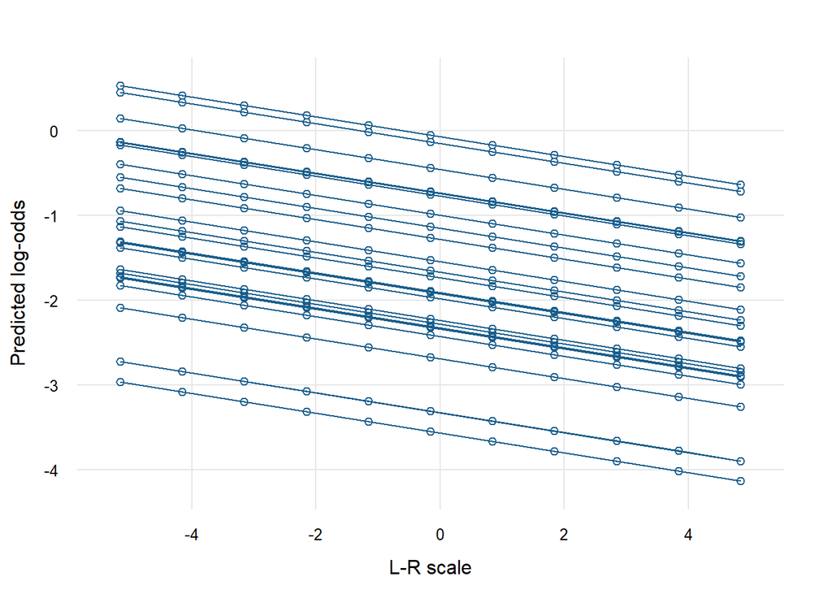

Figure 6. Relationship between `L-R scale` and predicted log odds of boycotting certain products for `model_21`.

```r
xyplot(predlogit ~ lrscale_cntrd,
       data = logodds_21,
       groups = cntry,
       type = c("p","l","g"),
       col = color,
       xlab = "L-R scale",
       ylab = "Predicted log-odds",
       par.settings = list(axis.line = list(col = 0)))
```

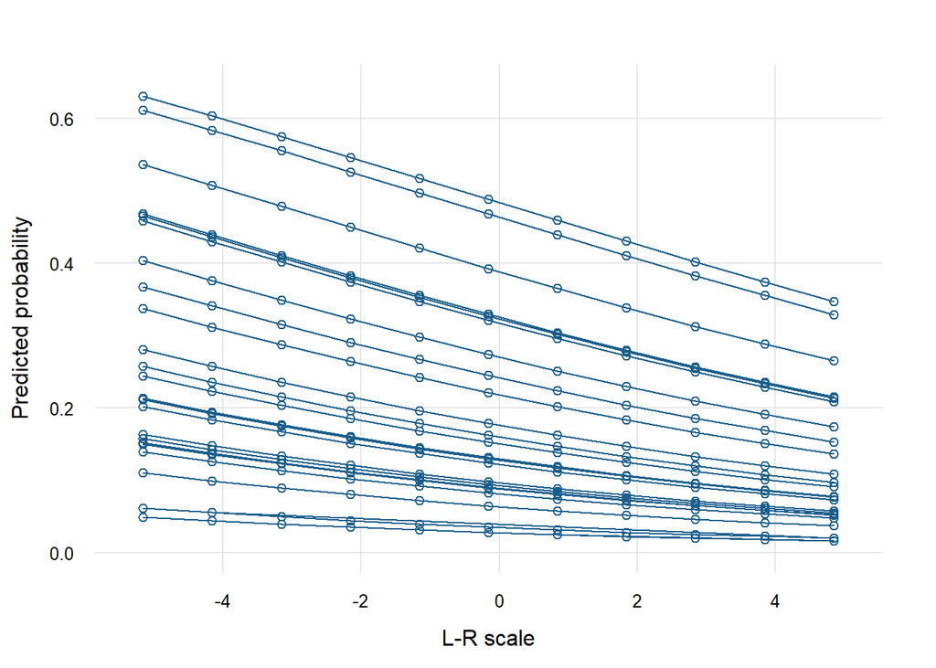

Figure 7. Relationship between `L-R scale` and probability of boycotting certain products for `model_21`.

```r
xyplot(predproba ~ lrscale_cntrd,
       data = probas_21,
       groups = cntry,
       type = c("p","l","g"),
       col = color,
       xlab = "L-R scale",
       ylab = "Predicted probability",
       par.settings = list(axis.line = list(col = 0)))
```

## Random effects model (8 points)

#### Fit a random effects model with centered conservatism as a sole level-1 predictor.

```r
model_22 <- glmer(bctprd ~ lrscale_centered + (lrscale_centered | cntry), family = binomial, data = data_2)

summary_22 <- summary(model_22)

summary_22
```

```
## Generalized linear mixed model fit by maximum likelihood (Laplace
##   Approximation) [glmerMod]
##  Family: binomial  ( logit )
## Formula: bctprd ~ lrscale_centered + (lrscale_centered | cntry)
##    Data: data_2
##
##      AIC      BIC   logLik deviance df.resid
##  33848.5  33891.2 -16919.2  33838.5    38237
##
## Scaled residuals:
##     Min      1Q  Median      3Q     Max
## -1.4292 -0.5215 -0.3347 -0.1922  6.8495
##
## Random effects:
##  Groups Name             Variance Std.Dev. Corr
##  cntry  (Intercept)      0.859072 0.92686
##         lrscale_centered 0.007034 0.08387  -0.42
## Number of obs: 38242, groups:  cntry, 23
##
## Fixed effects:
##                  Estimate Std. Error z value Pr(>|z|)
## (Intercept)      -1.67451    0.19479  -8.597  < 2e-16 ***
## lrscale_centered -0.10830    0.01909  -5.674 1.39e-08 ***
## ---
## Signif. codes:  0 '***' 0.001 '**' 0.01 '*' 0.05 '.' 0.1 ' ' 1
##
## Correlation of Fixed Effects:
##             (Intr)
## lrscl_cntrd -0.379
```

#### a) Is this model better than the fixed effects model? Provide the results of an appropriate test and interpret it.

```r
lrtest(model_21, model_22)
```

```
## Likelihood ratio test
##
## Model 1: bctprd ~ lrscale_centered + (1 | cntry)
## Model 2: bctprd ~ lrscale_centered + (lrscale_centered | cntry)
##   #Df LogLik Df  Chisq Pr(>Chisq)
## 1   3 -16973
## 2   5 -16919  2 107.94  < 2.2e-16 ***
## ---
## Signif. codes:  0 '***' 0.001 '**' 0.01 '*' 0.05 '.' 0.1 ' ' 1
```

Yes, the `model_22` is better than `model_21` ($\chi^2 = 107.94$; $df=2$; $p<.001$).

Association between conservatism and boycotting products is different in different countries (we can expect non-parallel slopes).

#### b) What is the estimated value of the intercept? Transform it into probability and interpret the value that you received.

```r
model_22_gamma_00 <- summary_22$coefficients[1, 1]
model_22_proba <- exp(model_22_gamma_00) / (1+exp(model_22_gamma_00))

cat(" Estimate for the intercept:", model_22_gamma_00, "\n",
    "Probability of boycotting certain products in the last 12 months:", model_22_proba)
```

```
##  Estimate for the intercept: -1.674507
##  Probability of boycotting certain products in the last 12 months: 0.1578242
```

Probability of boycotting certain products in the last 12 months equals $16$% for the mean value of conservatism (`lrscale_centered`).

#### c) What is the estimated value of the slope? How would you interpret it?

```r
model_22_slope <- summary_22$coefficients[2, 1]
model_22_proba <- exp(model_22_slope) / (1+exp(model_22_slope))

cat(" Estimate for the slope:", model_22_slope)
```

```
##  Estimate for the slope: -0.1083045
```

Estimated value of the slope equals $-.11$. It means that the more conservative the person the less likely the person to boycott certain products in the last 12 months.

#### d) Visualize intercepts and slopes across different countries using sjPlot library

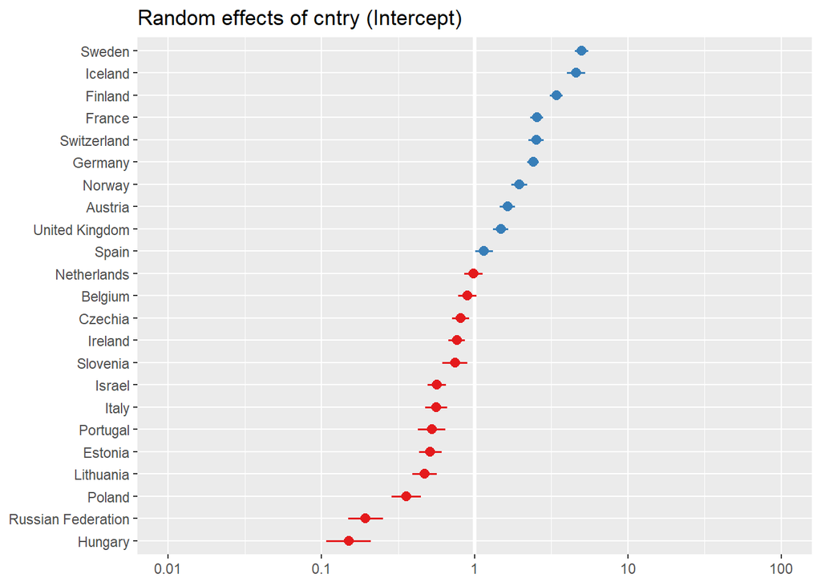

Figure 8. Variablilty of intercept [1] and slope [2] for `model_22`.

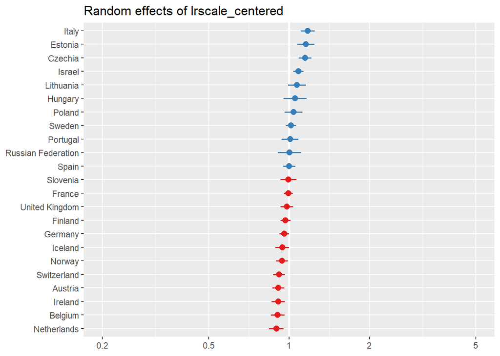

Figure 8. Variablilty of intercept [1] and slope [2] for `model_22`.

```r
plot_model(model_22,
           type = "re",
           sort.est = "sort.all",
           grid = FALSE,
           free.scale = FALSE)
```

#### e) Create two plots: one presenting the relationship between conservatism and predicted log odds of boycotting certain products across different countries and the other showing the association between conservatism and probability of boycotting across different countries

```r
# Get predicted probas for our training data
predproba_22 <- fitted(model_22)

# Get predicted log odds
predlogit_22 <- logit(predproba_22)

# Create new DFs with `cntry`, `clrscale` and our DVs logits & probas
logodds_22 <- unique(data.frame(cbind(predlogit     = predlogit_22,
                                      cntry         = data_2$cntry,
                                      lrscale_cntrd = data_2$lrscale_centered)))


probas_22 <- unique(data.frame(cbind(predproba     = predproba_22,
                                     cntry         = data_2$cntry,
                                     lrscale_cntrd = data_2$lrscale_centered)))
```

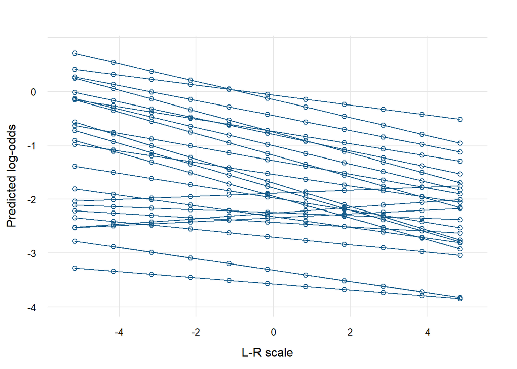

Figure 9. Relationship between `L-R scale` and predicted log odds of boycotting certain products for `model_22`.

```r
xyplot(predlogit ~ lrscale_cntrd,
       data = logodds_22,
       groups = cntry,
       type = c("p","l","g"),
       col = color,
       xlab = "L-R scale",
       ylab = "Predicted log-odds",
       par.settings = list(axis.line = list(col = 0)))
```

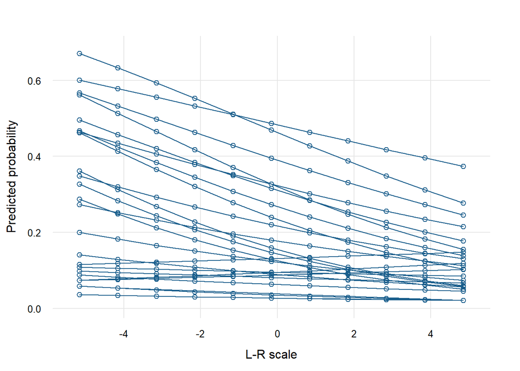

Figure 10. Relationship between `L-R scale` and probability of boycotting certain products for `model_22`.

```r
xyplot(predproba ~ lrscale_cntrd,
       data = probas_22,
       groups = cntry,
       type = c("p","l","g"),
       col = color,
       xlab = "L-R scale",
       ylab = "Predicted probability",
       par.settings = list(axis.line = list(col = 0)))
```

#### f) Provide the estimated values of intercepts and slopes for Sweden and Poland (**1 EXTRA POINT**).

```r
# Get random and fixed effects slopes and intercepts
ranef(model_22)
```

```
## $cntry
##                    (Intercept) lrscale_centered
## Austria             0.49162552    -0.0921092157
## Belgium            -0.11184649    -0.0982743523
## Switzerland         0.92197695    -0.0860217137
## Czechia            -0.21230710     0.1366912451
## Germany             0.87766074    -0.0427871629
## Estonia            -0.66705660     0.1437602688
## Spain               0.13917093     0.0002509821
## Finland             1.22900506    -0.0307418058
## France              0.93477245    -0.0064104808
## United Kingdom      0.39293789    -0.0185698495
## Hungary            -1.89539170     0.0508007351
## Ireland            -0.26964143    -0.0932400675
## Israel             -0.57265229     0.0814134901
## Iceland             1.52633304    -0.0589091671
## Italy              -0.57975335     0.1601724018
## Lithuania          -0.75230677     0.0669295815
## Netherlands        -0.02227442    -0.1107345924
## Norway              0.66897076    -0.0611078564
## Poland             -1.02581918     0.0381835911
## Portugal           -0.64509159     0.0086513072
## Russian Federation -1.64015476     0.0031762636
## Sweden              1.60766986     0.0157693994
## Slovenia           -0.29853555    -0.0056192508
##
## with conditional variances for "cntry"
```

```r
sweden_raw_22 <- c( 1.60766986, 0.0157693994)
poland_raw_22 <- c(-1.02581918, 0.0381835911)

fixd_eff_22 <- fixef(model_22)

# Compute values
cat("                         Intercept   Slope\n",
     "Estimates for Sweden:", fixd_eff_22 + sweden_raw_22, "\n",
     "Estimates for Poland:", fixd_eff_22 + poland_raw_22)
```

```
##                          Intercept   Slope
##  Estimates for Sweden: -0.06683744 -0.09253507
##  Estimates for Poland: -2.700326 -0.07012087
```

#### g) Compute the predicted probability of boycotting certain products for a person who has extremely leftist views (`lrscore == 0`) and lives in Sweden. Next, compute such probability for an extreme leftist (`lrscore == 0`) living in Poland. Compare the probabilities and interpret the difference (**2 EXTRA POINTS**).

```r
# Get predictions
sweden_pred_22 <- predict(model_22,
                          data.frame(lrscale_centered = 0 - mean(data_2$lrscale), cntry='Sweden'),
                          type = 'response')

poland_pred_22 <- predict(model_22,
                          data.frame(lrscale_centered = 0 - mean(data_2$lrscale), cntry='Poland'),
                          type = 'response')

cat(" Probability of boycott for Swedish person with `lrscale == 0`:", sweden_pred_22, "\n",
     "Probability of boycott for Polish  person with `lrscale == 0`:", poland_pred_22, "\n",
     "Ratio:", sweden_pred_22 / poland_pred_22)
```

```
##  Probability of boycott for Swedish person with `lrscale == 0`: 0.6011919
##  Probability of boycott for Polish  person with `lrscale == 0`: 0.08797122
##  Ratio: 6.83396
```

It’s $6.83$ times more probable that Swedish extereme leftist (`lrscale == 0`) boycotted certain products in the last 12 months than Polish extereme leftist (`lrscale == 0`) did so.

## Cross-level interaction (10 points)

#### Fit a model including centered conservatism as a random level-1 predictor, full_democracy as a level-2 predictor and centered conservatism × full_democracy crosslevel interaction.

```r
model_23 <- glmer(bctprd ~ lrscale_centered * full_democracy + (lrscale_centered | cntry),
                  family = binomial,
                  data = data_2)

summary_23 <- summary(model_23)

summary_23
```

```
## Generalized linear mixed model fit by maximum likelihood (Laplace
##   Approximation) [glmerMod]
##  Family: binomial  ( logit )
## Formula: bctprd ~ lrscale_centered * full_democracy + (lrscale_centered |
##     cntry)
##    Data: data_2
##
##      AIC      BIC   logLik deviance df.resid
##  33829.3  33889.1 -16907.6  33815.3    38235
##
## Scaled residuals:
##     Min      1Q  Median      3Q     Max
## -1.4216 -0.5258 -0.3338 -0.1922  6.9999
##
## Random effects:
##  Groups Name             Variance Std.Dev. Corr
##  cntry  (Intercept)      0.424194 0.65130
##         lrscale_centered 0.004009 0.06332  0.09
## Number of obs: 38242, groups:  cntry, 23
##
## Fixed effects:
##                                 Estimate Std. Error z value Pr(>|z|)
## (Intercept)                     -2.30199    0.18813 -12.236  < 2e-16 ***
## lrscale_centered                -0.05703    0.02192  -2.602  0.00926 **
## full_democracy                   1.31383    0.27197   4.831 1.36e-06 ***
## lrscale_centered:full_democracy -0.10776    0.03027  -3.560  0.00037 ***
## ---
## Signif. codes:  0 '***' 0.001 '**' 0.01 '*' 0.05 '.' 0.1 ' ' 1
##
## Correlation of Fixed Effects:
##             (Intr) lrscl_ fll_dm
## lrscl_cntrd  0.077
## full_dmcrcy -0.690 -0.053
## lrscl_cnt:_ -0.055 -0.722  0.082
```

#### a) Is this model better than the random effects model? Provide the results of an appropriate test

```r
lrtest(model_22, model_23)
```

```
## Likelihood ratio test
##
## Model 1: bctprd ~ lrscale_centered + (lrscale_centered | cntry)
## Model 2: bctprd ~ lrscale_centered * full_democracy + (lrscale_centered |
##     cntry)
##   #Df LogLik Df  Chisq Pr(>Chisq)
## 1   5 -16919
## 2   7 -16908  2 23.207  9.136e-06 ***
## ---
## Signif. codes:  0 '***' 0.001 '**' 0.01 '*' 0.05 '.' 0.1 ' ' 1
```

Yes, the `model_23` is better than `model_22` ($\Delta\chi^2 = 23.207$; $df=2$; $p<.001$).

#### b) Is the effect of conservatism on boycotting certain products different in full democracies and not fully democratic countries? How do you know it?

```r
# Add reverse-coding `full_democracy`
data_2$no_democracy<-recode(data_2$full_democracy,'0=1;1=0')

# Fit the model with recoded `full_democracy`
model_23a <- glmer(bctprd ~ lrscale_centered * no_democracy + (lrscale_centered | cntry),
                  family = binomial,
                  data   = data_2)

summary_23a <- summary(model_23a)

summary_23a
```

```
## Generalized linear mixed model fit by maximum likelihood (Laplace
##   Approximation) [glmerMod]
##  Family: binomial  ( logit )
## Formula: bctprd ~ lrscale_centered * no_democracy + (lrscale_centered |
##     cntry)
##    Data: data_2
##
##      AIC      BIC   logLik deviance df.resid
##  33829.3  33889.1 -16907.6  33815.3    38235
##
## Scaled residuals:
##     Min      1Q  Median      3Q     Max
## -1.4216 -0.5258 -0.3338 -0.1922  6.9999
##
## Random effects:
##  Groups Name             Variance Std.Dev. Corr
##  cntry  (Intercept)      0.42419  0.65130
##         lrscale_centered 0.00401  0.06332  0.09
## Number of obs: 38242, groups:  cntry, 23
##
## Fixed effects:
##                               Estimate Std. Error z value Pr(>|z|)
## (Intercept)                   -0.98815    0.19474  -5.074 3.89e-07 ***
## lrscale_centered              -0.16479    0.02093  -7.873 3.47e-15 ***
## no_democracy                  -1.31385    0.26866  -4.890 1.01e-06 ***
## lrscale_centered:no_democracy  0.10776    0.03027   3.561  0.00037 ***
## ---
## Signif. codes:  0 '***' 0.001 '**' 0.01 '*' 0.05 '.' 0.1 ' ' 1
##
## Correlation of Fixed Effects:
##             (Intr) lrscl_ n_dmcr
## lrscl_cntrd  0.088
## no_democrcy -0.713 -0.062
## lrscl_cnt:_ -0.059 -0.690  0.082
```

```r
# Compare estimates for `full_democracy` (`model_23`) and `no_democracy` (`model_23a`) models
cat(" Model                   Estimate    Std. Error  z value     Pr(>|z|) \n",
    "Non-full democracies :", "\n",
    "              (Slope):", formatC(summary_23$coefficients[2, ], digits = 8, format = 'f'), "\n",
    "Full democracies     :", "\n",
    "              (Slope):", formatC(summary_23a$coefficients[2, ], digits = 8, format = 'f'))
```

```
##  Model                   Estimate    Std. Error  z value     Pr(>|z|)
##  Non-full democracies :
##                (Slope): -0.05703314 0.02191715 -2.60221484 0.00926238
##  Full democracies     :
##                (Slope): -0.16479227 0.02093253 -7.87254533 0.00000000
```

Yes, the effect is different for fully democratic and not fully democratic coutries.

We know this because slope estimates for `full_democracy` and `no_democracy` differ (check the code output above).

#### c) What is the estimated value of the intercept? How would you interpret it?

```r
# I am assuming that the question is related to the basic model (`model_23`)
summary_23$coefficients[1, ]
```

```
##      Estimate    Std. Error       z value      Pr(>|z|)
## -2.301991e+00  1.881342e-01 -1.223590e+01  1.998810e-34
```

The value of the intercept equals to $-2.30$. It’s the value of log-odds of boycotting certain prod. in the last 12 months when `full_demoracy == 0` and `lrscale_centered == 0`.

#### d) What is the estimated value of the slope? How would you interpret it?

```r
# I am assuming that the question is related to the basic model (`model_23`)
summary_23$coefficients[2, ]
```

```
##     Estimate   Std. Error      z value     Pr(>|z|)
## -0.057033137  0.021917152 -2.602214841  0.009262381
```

The value of the slope equals to $-0.05$. It means that the more conservative the person is the less likely this person is to boycott certain products in the last 12 months.

#### e) Provide the estimates (as well as standard errors and p-values) of the intercepts and slopes in full democracies and countries that are not full democracies.

```r
cat(" Model                   Estimate    Std. Error  z value     Pr(>|z|) \n",
    "Non-full democracies :", "\n",
    "          (Intercept):", formatC(summary_23$coefficients[1, ], digits = 8, format = 'f'), "\n",
    "              (Slope):", formatC(summary_23$coefficients[2, ], digits = 8, format = 'f'), "\n",
    "Full democracies     :", "\n",
    "          (Intercept):", formatC(summary_23a$coefficients[1, ], digits = 8, format = 'f'), "\n",
    "              (Slope):", formatC(summary_23a$coefficients[2, ], digits = 8, format = 'f'))
```

```
##  Model                   Estimate    Std. Error  z value     Pr(>|z|)
##  Non-full democracies :
##            (Intercept): -2.30199090 0.18813420 -12.23589837 0.00000000
##                (Slope): -0.05703314 0.02191715 -2.60221484 0.00926238
##  Full democracies     :
##            (Intercept): -0.98815008 0.19473525 -5.07432576 0.00000039
##                (Slope): -0.16479227 0.02093253 -7.87254533 0.00000000
```

#### f) Visualize the effects of conservatism on the outcome variable in full democracies and countries that are not full democracies.

```r
# Prepare data
ef_23 <- effect(term    = "lrscale_centered * full_democracy",
                mod     = model_23,
                xlevels = list(lrscale_centered = seq(-5, 5, 1),
                               full_democracy   = c(0,1)))

ef_df_23 <- as.data.frame(ef_23)

# Transform `full_democracy` to factor (for viz)
ef_df_23$full_democracy <- as.factor(ef_df_23$full_democracy)
```

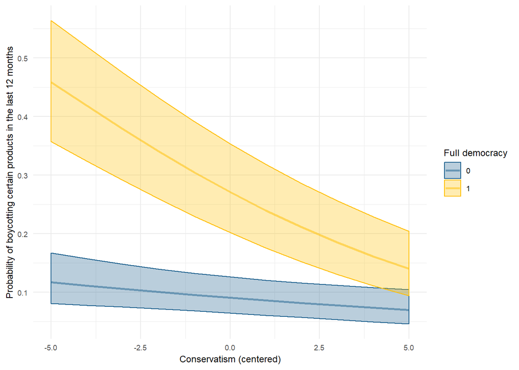

Figure 11. Cross-level interaction between conservatism (`L-R scale (centered)`) and `full_democracy` (0 = non-full democracy; 1 = full democracy).

```r
ggplot(ef_df_23,
       aes(x     = lrscale_centered,
           y     = fit,
           color = full_democracy,
           group = full_democracy)) +
  geom_line(size = 1, alpha = .5) +
  geom_ribbon(aes(ymin = lower,
                  ymax = upper,
                  fill = full_democracy),
              alpha = .3) +
  labs(x     = "Conservatism (centered)",
       y     = "Probability of boycotting certain products in the last 12 months",
       fill  = "Full democracy",
       color = "Full democracy") +
  theme_minimal() +
  theme(text=element_text(size=9)) +
  scale_color_manual(values=c(color, color4)) +
  scale_fill_manual(values=c(color, color4))
```

#### g) Compute the predicted probability of boycotting certain products for a person who has extremely conservative views (`lrscore == 10`) and lives in a fully democratic country. Next, compute such a probability for an extreme conservatist (`lrscore == 10`) living in a country that is not a full democracy. Compare the probabilities and interpret the difference (**2 EXTRA POINTS**).

```r
# Get predictions
fulldem_pred_23 <- predict(model_23,
                          data.frame(lrscale_centered = 10 - mean(data_2$lrscale),
                                     full_democracy   = 1),
                          type    = 'response',
                          re.form = ~0)

nflldem_pred_23 <- predict(model_23,
                          data.frame(lrscale_centered = 10 - mean(data_2$lrscale),
                                     full_democracy   = 0),
                          type    = 'response',
                          re.form = ~0)

cat(" Probability of boycott for a person from     a fully democratic country with `lrscale == 10`:", fulldem_pred_23, "\n",
     "Probability of boycott for a person from not a fully democratic country with `lrscale == 10`:", nflldem_pred_23, "\n",
     "Ratio:", fulldem_pred_23 / nflldem_pred_23)
```

```
##  Probability of boycott for a person from     a fully democratic country with `lrscale == 10`: 0.1435499
##  Probability of boycott for a person from not a fully democratic country with `lrscale == 10`: 0.07055726
##  Ratio: 2.034516
```

It’s $2.03$ times more probable that an extereme conservatist (`lrscale == 10`) from a fully democratic country boycotted certain products in the last 12 months than that an extereme conservatist (`lrscale == 10`) from a non-fully democratic country did so.

## Model with a covariate (4 points)

#### Fit a model including centered conservatism as a random level-1 predictor, full_democracy as a level-2 predictor, centered gdp as a level-2 covariate, centered conservatism × full_democracy cross-level interaction, and centered conservatism × centered gdp cross-level interaction.

```r
model_24 <- glmer(bctprd ~ lrscale_centered * full_democracy + lrscale_centered * gdp_centered + (lrscale_centered | cntry),
                  family = binomial,
                  data = data_2)

summary_24 <- summary(model_24)

summary_24
```

```
## Generalized linear mixed model fit by maximum likelihood (Laplace
##   Approximation) [glmerMod]
##  Family: binomial  ( logit )
## Formula: bctprd ~ lrscale_centered * full_democracy + lrscale_centered *
##     gdp_centered + (lrscale_centered | cntry)
##    Data: data_2
##
##      AIC      BIC   logLik deviance df.resid
##  33825.6  33902.6 -16903.8  33807.6    38233
##
## Scaled residuals:
##     Min      1Q  Median      3Q     Max
## -1.4250 -0.5226 -0.3370 -0.1915  6.9748
##
## Random effects:
##  Groups Name             Variance Std.Dev. Corr
##  cntry  (Intercept)      0.346026 0.58824
##         lrscale_centered 0.003514 0.05928  0.25
## Number of obs: 38242, groups:  cntry, 23
##
## Fixed effects:
##                                 Estimate Std. Error z value Pr(>|z|)
## (Intercept)                     -1.99496    0.21146  -9.434   <2e-16 ***
## lrscale_centered                -0.07685    0.02475  -3.105   0.0019 **
## full_democracy                   0.67245    0.36266   1.854   0.0637 .
## gdp_centered                     0.22036    0.09522   2.314   0.0207 *
## lrscale_centered:full_democracy -0.06484    0.04164  -1.557   0.1195
## lrscale_centered:gdp_centered   -0.01539    0.01111  -1.386   0.1657
## ---
## Signif. codes:  0 '***' 0.001 '**' 0.01 '*' 0.05 '.' 0.1 ' ' 1
##
## Correlation of Fixed Effects:
##                (Intr) lrscl_ fll_dm gdp_cn lrscl_cntrd:f_
## lrscl_cntrd     0.216
## full_dmcrcy    -0.812 -0.177
## gdp_centerd     0.596  0.132 -0.739
## lrscl_cntrd:f_ -0.181 -0.811  0.224 -0.167
## lrscl_cntrd:g_  0.132  0.539 -0.164  0.219 -0.724
```

#### a) Is this model better than the cross-level interaction model? Provide the results of an appropriate test

```r
lrtest(model_23, model_24)
```

```
## Likelihood ratio test
##
## Model 1: bctprd ~ lrscale_centered * full_democracy + (lrscale_centered |
##     cntry)
## Model 2: bctprd ~ lrscale_centered * full_democracy + lrscale_centered *
##     gdp_centered + (lrscale_centered | cntry)
##   #Df LogLik Df  Chisq Pr(>Chisq)
## 1   7 -16908
## 2   9 -16904  2 7.6323    0.02201 *
## ---
## Signif. codes:  0 '***' 0.001 '**' 0.01 '*' 0.05 '.' 0.1 ' ' 1
```

Yes, the `model_24` is better than `model_23` ($\Delta\chi^2 = 7.632$; $df=2$; $p=.02$).

#### b) Is centered conservatism × full_democracy cross-level interaction still significant? What does it mean?

```r
summary_24$coefficients[5, ]
```

```
##    Estimate  Std. Error     z value    Pr(>|z|)
## -0.06483871  0.04164122 -1.55708001  0.11945149
```

No, it’s not significant any more. We can interpret it as a result of mediation of `gdp_centered`:

`gdp_centered` mediated the relationship between the interaction `lrscale_centered * full_democracy` and our DV.

## Table (2 points)

#### Provide a publication-quality table summarizing all models you have just tested. You can find an example of such table in Class 8 slides.

```r
# The below code returned bullshit results -> Table 2 in additional file!
tab_model(model_20, model_21, model_22, model_23, model_24,

          show.ci      = FALSE,
          show.dev     = TRUE,
          show.r2      = FALSE,
          show.ngroups = FALSE,
          show.obs     = FALSE,
          p.style      = 'asterisk',

          pred.labels = c("Intercept",
                          "Conservatism",
                          "Full democracy",
                          "Conservatism x full dem.",
                          "GDP",
                          "Conservatism x GDP"),

          dv.labels   = c("Model 0",
                          "Model 1",
                          "Model 2",
                          "Model 3",
                          "Model 4"),

          transform   = NULL,

          title = "Table 2. Comparison of models: `model_20`, `model_21`, `model_22`, `model_23`, `model_24`")
```

Table 2. Comparison of models: `model_20`, `model_21`, `model_22`, `model_23`, `model_24`

Model 0

Model 1

Model 2

Model 3

Model 4

Predictors

Log-Odds

Log-Odds

Log-Odds

Log-Odds

Log-Odds

Intercept

-1.65 ***

-1.67 ***

-1.67 ***

-2.30 ***

-1.99 ***

Conservatism

-0.12 ***

-0.11 ***

-0.06 **

-0.08 **

Full democracy

1.31 ***

0.67

Conservatism x full dem.

-0.11 ***

-0.06

GDP

0.22 *

Conservatism x GDP

-0.02

Random Effects

σ<sup>2</sup>

3.29

3.29

3.29

3.29

3.29

τ<sub>00</sub>

0.87 <sub>cntry</sub>

0.86 <sub>cntry</sub>

0.86 <sub>cntry</sub>

0.42 <sub>cntry</sub>

0.35 <sub>cntry</sub>

τ<sub>11</sub>

0.01 <sub>cntry.lrscale_centered</sub>

0.00 <sub>cntry.lrscale_centered</sub>

0.00 <sub>cntry.lrscale_centered</sub>

ρ<sub>01</sub>

-0.42 <sub>cntry</sub>

0.09 <sub>cntry</sub>

0.25 <sub>cntry</sub>

ICC

0.21

0.21

0.21

0.12

0.10

Deviance

34292.811

33946.398

33838.457

33815.251

33807.618

- p<0.05 ** p<0.01 *** p<0.001